# week5_머신러닝

## 과제

#### 본인이 관심있는 분야의 데이터셋을 분석 예측하시면 됩니다

#### 포트폴리오 만든다고 생각하고 주석 , 출처 , 프로젝트 폴더 구조 등 고려해서 진행해주세요

- 머신러닝 흐름 (불러오기 -> 전처리 -> 모델 선정)만 녹여내시면 반려하지 않습니다.
- 우수과제에 관심 있는 분들은:
- pipeline, OOP, modular, autoML 등 새로운 방식을 사용하는 경우
- time series, unstructured, big data, (very) small data 등 기존에 다루지 않았거나 다루기 힘든 데이터를 다루는 경우
- 전반적인 프로젝트가 잘 정리(repository 구조 등)되었고 가독성이 높은 경우에 가점을 드리겠습니다.

## 0. 불러오기 등 준비

```python
## 준비
print('Ran on Jupyter Notebook')

import sys
print(sys.version) # 파이썬 버전
print(sys.executable) # 파이썬 위치
import os
print(os.getcwd()) # 폴더 위치

import inspect
from datetime import datetime

# import pixiedust # 디버깅 툴
# %%pixie_debugger

from IPython.core.display import display, HTML # 셀이 화면 전체 채우도록 함
display(HTML("<style>.container { width:100% !important; }</style>"))
```

```
Ran on Jupyter Notebook
3.7.3 (default, Apr 24 2019, 15:29:51) [MSC v.1915 64 bit (AMD64)]
C:\Users\MiSung\Anaconda3\python.exe
C:\Users\MiSung\Desktop\5week_practicalML_Minsung_verified
```

```python
## 자주 쓰는 모듈들
import pandas as pd
import numpy as np

import sklearn
from sklearn import datasets
from sklearn.model_selection import GridSearchCV
from sklearn.model_selection import RandomizedSearchCV
from sklearn.model_selection import train_test_split
from sklearn.model_selection import cross_val_score
from sklearn import metrics

%matplotlib inline
import matplotlib.pyplot as plt
import seaborn as sns
color = sns.color_palette()
sns.set_style('darkgrid')
```

```python
from sklearn.datasets import load_boston

from sklearn.linear_model import LinearRegression
from sklearn.preprocessing import StandardScaler
from sklearn.svm import SVC
from sklearn import metrics

import pickle
```

```python
# 그래프에서 한글을 사용하기 위해 한글폰트를 적용
# 맑은 고딕을 사용하겠습니다 !
plt.style.use('seaborn') # seaborn 스타일로 변환 (기본은 못생겼어요..)
plt.rc('font', family='Malgun Gothic')
plt.rc('axes', unicode_minus=False)
```

## 사용할 데이터 : Gender Recognition by Voice

- https://www.kaggle.com/primaryobjects/voicegender

### Voice Gender

- Gender Recognition by Voice and Speech Analysis
- This database was created to identify a voice as male or female, based upon acoustic properties of the voice and speech. The dataset consists of 3,168 recorded voice samples, collected from male and female speakers. The voice samples are pre-processed by acoustic analysis in R using the seewave and tuneR packages, with an analyzed frequency range of 0hz-280hz (human vocal range).

### The Dataset

The following acoustic properties of each voice are measured and included within the CSV:

```
meanfreq: mean frequency (in kHz)
sd: standard deviation of frequency
median: median frequency (in kHz)
Q25: first quantile (in kHz)
Q75: third quantile (in kHz)
IQR: interquantile range (in kHz)
skew: skewness (see note in specprop description)
kurt: kurtosis (see note in specprop description)
sp.ent: spectral entropy
sfm: spectral flatness
mode: mode frequency
centroid: frequency centroid (see specprop)
peakf: peak frequency (frequency with highest energy)
meanfun: average of fundamental frequency measured across acoustic signal
minfun: minimum fundamental frequency measured across acoustic signal
maxfun: maximum fundamental frequency measured across acoustic signal
meandom: average of dominant frequency measured across acoustic signal
mindom: minimum of dominant frequency measured across acoustic signal
maxdom: maximum of dominant frequency measured across acoustic signal
dfrange: range of dominant frequency measured across acoustic signal
modindx: modulation index. Calculated as the accumulated absolute difference between adjacent measurements of fundamental frequencies divided by the frequency range
label: male or female
```

```
meanfreq : 평균 주파수 (kHz)
sd : 주파수의 표준 편차
median : 중앙 주파수 (kHz)
Q25 : 첫 번째 Quantile (kHz)
Q75 : 3 분위 (kHz)
IQR : 양자 간 범위 (kHz)
skew : 왜도 (specprop 설명에서 참고 참조)
kurt: 첨도 (specprop 설명에서 참고 참조)
sp.ent : 스펙트럼 엔트로피
sfm : 스펙트럼 평탄도
mode: 모드 주파수
centroid : 주파수 중심 (specprop 참조)
peakf : 피크 주파수 (에너지가 가장 높은 주파수)
meanfun : 음향 신호에서 측정 된 기본 주파수의 평균
minfun : 음향 신호에서 측정 된 최소 기본 주파수
maxfun : 음향 신호에서 측정 된 최대 기본 주파수
meandom : 음향 신호에서 측정 된 주요 주파수의 평균
mindom : 음향 신호에서 측정 된 주요 주파수의 최소값
maxdom : 음향 신호에서 측정 된 주요 주파수의 최대 값
dfrange : 음향 신호에서 측정 된 주요 주파수 범위
modindx : 변조 지수. 기본 주파수의 인접 측정 값을 주파수 범위로 나눈 누적 누적 절대 값으로 계산
label : 남성 또는 여성
```

#### 데이터를 불러와서 생긴모습을 봐보자!

```python
df = pd.read_csv('voice.csv')
```

```python
# Pandas 출력 최대치 설정, 열41개, 행 20개
pd.set_option('max_columns', 21,'max_rows', 20)
```

```python
df.head()
```

|  | meanfreq | sd | median | Q25 | Q75 | IQR | skew | kurt | sp.ent | sfm | mode | centroid | meanfun | minfun | maxfun | meandom | mindom | maxdom | dfrange | modindx | label |
| --- | --- | --- | --- | --- | --- | --- | --- | --- | --- | --- | --- | --- | --- | --- | --- | --- | --- | --- | --- | --- | --- |
| 0 | 0.059781 | 0.064241 | 0.032027 | 0.015071 | 0.090193 | 0.075122 | 12.863462 | 274.402906 | 0.893369 | 0.491918 | 0.000000 | 0.059781 | 0.084279 | 0.015702 | 0.275862 | 0.007812 | 0.007812 | 0.007812 | 0.000000 | 0.000000 | male |
| 1 | 0.066009 | 0.067310 | 0.040229 | 0.019414 | 0.092666 | 0.073252 | 22.423285 | 634.613855 | 0.892193 | 0.513724 | 0.000000 | 0.066009 | 0.107937 | 0.015826 | 0.250000 | 0.009014 | 0.007812 | 0.054688 | 0.046875 | 0.052632 | male |
| 2 | 0.077316 | 0.083829 | 0.036718 | 0.008701 | 0.131908 | 0.123207 | 30.757155 | 1024.927705 | 0.846389 | 0.478905 | 0.000000 | 0.077316 | 0.098706 | 0.015656 | 0.271186 | 0.007990 | 0.007812 | 0.015625 | 0.007812 | 0.046512 | male |
| 3 | 0.151228 | 0.072111 | 0.158011 | 0.096582 | 0.207955 | 0.111374 | 1.232831 | 4.177296 | 0.963322 | 0.727232 | 0.083878 | 0.151228 | 0.088965 | 0.017798 | 0.250000 | 0.201497 | 0.007812 | 0.562500 | 0.554688 | 0.247119 | male |
| 4 | 0.135120 | 0.079146 | 0.124656 | 0.078720 | 0.206045 | 0.127325 | 1.101174 | 4.333713 | 0.971955 | 0.783568 | 0.104261 | 0.135120 | 0.106398 | 0.016931 | 0.266667 | 0.712812 | 0.007812 | 5.484375 | 5.476562 | 0.208274 | male |

```python
# 데이터 구조 확인
df.info()
```

```
<class 'pandas.core.frame.DataFrame'>
RangeIndex: 3168 entries, 0 to 3167
Data columns (total 21 columns):
meanfreq    3168 non-null float64
sd          3168 non-null float64
median      3168 non-null float64
Q25         3168 non-null float64
Q75         3168 non-null float64
IQR         3168 non-null float64
skew        3168 non-null float64
kurt        3168 non-null float64
sp.ent      3168 non-null float64
sfm         3168 non-null float64
mode        3168 non-null float64
centroid    3168 non-null float64
meanfun     3168 non-null float64
minfun      3168 non-null float64
maxfun      3168 non-null float64
meandom     3168 non-null float64
mindom      3168 non-null float64
maxdom      3168 non-null float64
dfrange     3168 non-null float64
modindx     3168 non-null float64
label       3168 non-null object
dtypes: float64(20), object(1)
memory usage: 519.8+ KB
```

```python
# 데이터 요약통계
df.describe()
```

|  | meanfreq | sd | median | Q25 | Q75 | IQR | skew | kurt | sp.ent | sfm | mode | centroid | meanfun | minfun | maxfun | meandom | mindom | maxdom | dfrange | modindx |
| --- | --- | --- | --- | --- | --- | --- | --- | --- | --- | --- | --- | --- | --- | --- | --- | --- | --- | --- | --- | --- |
| count | 3168.000000 | 3168.000000 | 3168.000000 | 3168.000000 | 3168.000000 | 3168.000000 | 3168.000000 | 3168.000000 | 3168.000000 | 3168.000000 | 3168.000000 | 3168.000000 | 3168.000000 | 3168.000000 | 3168.000000 | 3168.000000 | 3168.000000 | 3168.000000 | 3168.000000 | 3168.000000 |
| mean | 0.180907 | 0.057126 | 0.185621 | 0.140456 | 0.224765 | 0.084309 | 3.140168 | 36.568461 | 0.895127 | 0.408216 | 0.165282 | 0.180907 | 0.142807 | 0.036802 | 0.258842 | 0.829211 | 0.052647 | 5.047277 | 4.994630 | 0.173752 |
| std | 0.029918 | 0.016652 | 0.036360 | 0.048680 | 0.023639 | 0.042783 | 4.240529 | 134.928661 | 0.044980 | 0.177521 | 0.077203 | 0.029918 | 0.032304 | 0.019220 | 0.030077 | 0.525205 | 0.063299 | 3.521157 | 3.520039 | 0.119454 |
| min | 0.039363 | 0.018363 | 0.010975 | 0.000229 | 0.042946 | 0.014558 | 0.141735 | 2.068455 | 0.738651 | 0.036876 | 0.000000 | 0.039363 | 0.055565 | 0.009775 | 0.103093 | 0.007812 | 0.004883 | 0.007812 | 0.000000 | 0.000000 |
| 25% | 0.163662 | 0.041954 | 0.169593 | 0.111087 | 0.208747 | 0.042560 | 1.649569 | 5.669547 | 0.861811 | 0.258041 | 0.118016 | 0.163662 | 0.116998 | 0.018223 | 0.253968 | 0.419828 | 0.007812 | 2.070312 | 2.044922 | 0.099766 |
| 50% | 0.184838 | 0.059155 | 0.190032 | 0.140286 | 0.225684 | 0.094280 | 2.197101 | 8.318463 | 0.901767 | 0.396335 | 0.186599 | 0.184838 | 0.140519 | 0.046110 | 0.271186 | 0.765795 | 0.023438 | 4.992188 | 4.945312 | 0.139357 |
| 75% | 0.199146 | 0.067020 | 0.210618 | 0.175939 | 0.243660 | 0.114175 | 2.931694 | 13.648905 | 0.928713 | 0.533676 | 0.221104 | 0.199146 | 0.169581 | 0.047904 | 0.277457 | 1.177166 | 0.070312 | 7.007812 | 6.992188 | 0.209183 |
| max | 0.251124 | 0.115273 | 0.261224 | 0.247347 | 0.273469 | 0.252225 | 34.725453 | 1309.612887 | 0.981997 | 0.842936 | 0.280000 | 0.251124 | 0.237636 | 0.204082 | 0.279114 | 2.957682 | 0.458984 | 21.867188 | 21.843750 | 0.932374 |

```python
# 결측치 있는 열 확인 (덧셈은 행들의 값을 더해야하니까 axis=0)
# 결측치가 없군요!
df.isnull().sum(axis=0)
```

```
meanfreq    0
sd          0
median      0
Q25         0
Q75         0
IQR         0
skew        0
kurt        0
sp.ent      0
sfm         0
           ..
centroid    0
meanfun     0
minfun      0
maxfun      0
meandom     0
mindom      0
maxdom      0
dfrange     0
modindx     0
label       0
Length: 21, dtype: int64
```

```python
df['label'].value_counts()  #남자데이터 , 여자데이터의 수가 동일하다는것을 확인할수 있다. 따로 oversampling, undersampling 안해줘도 된다.
```

```
female    1584
male      1584
Name: label, dtype: int64
```

```python
# 지금 만들어진 dataframe을 볼수 있다.

%whos DataFrame
```

```
Variable   Type         Data/Info
---------------------------------
df         DataFrame          meanfreq        sd <...>n[3168 rows x 21 columns]
```

## 1. 데이터 전처리 및 시각화

```python
def transform_to_number(x):
    if x == 'male':
        return 1   # 남자면 1로
    else:
        return 0   # 여자면 0으로
```

```python
df['label'] = df['label'].apply(transform_to_number)
```

```python
# label 이 0과 1로 바뀐것을 볼수 있다.
df
```

|  | meanfreq | sd | median | Q25 | Q75 | IQR | skew | kurt | sp.ent | sfm | mode | centroid | meanfun | minfun | maxfun | meandom | mindom | maxdom | dfrange | modindx | label |
| --- | --- | --- | --- | --- | --- | --- | --- | --- | --- | --- | --- | --- | --- | --- | --- | --- | --- | --- | --- | --- | --- |
| 0 | 0.059781 | 0.064241 | 0.032027 | 0.015071 | 0.090193 | 0.075122 | 12.863462 | 274.402906 | 0.893369 | 0.491918 | 0.000000 | 0.059781 | 0.084279 | 0.015702 | 0.275862 | 0.007812 | 0.007812 | 0.007812 | 0.000000 | 0.000000 | 1 |
| 1 | 0.066009 | 0.067310 | 0.040229 | 0.019414 | 0.092666 | 0.073252 | 22.423285 | 634.613855 | 0.892193 | 0.513724 | 0.000000 | 0.066009 | 0.107937 | 0.015826 | 0.250000 | 0.009014 | 0.007812 | 0.054688 | 0.046875 | 0.052632 | 1 |
| 2 | 0.077316 | 0.083829 | 0.036718 | 0.008701 | 0.131908 | 0.123207 | 30.757155 | 1024.927705 | 0.846389 | 0.478905 | 0.000000 | 0.077316 | 0.098706 | 0.015656 | 0.271186 | 0.007990 | 0.007812 | 0.015625 | 0.007812 | 0.046512 | 1 |
| 3 | 0.151228 | 0.072111 | 0.158011 | 0.096582 | 0.207955 | 0.111374 | 1.232831 | 4.177296 | 0.963322 | 0.727232 | 0.083878 | 0.151228 | 0.088965 | 0.017798 | 0.250000 | 0.201497 | 0.007812 | 0.562500 | 0.554688 | 0.247119 | 1 |
| 4 | 0.135120 | 0.079146 | 0.124656 | 0.078720 | 0.206045 | 0.127325 | 1.101174 | 4.333713 | 0.971955 | 0.783568 | 0.104261 | 0.135120 | 0.106398 | 0.016931 | 0.266667 | 0.712812 | 0.007812 | 5.484375 | 5.476562 | 0.208274 | 1 |
| 5 | 0.132786 | 0.079557 | 0.119090 | 0.067958 | 0.209592 | 0.141634 | 1.932562 | 8.308895 | 0.963181 | 0.738307 | 0.112555 | 0.132786 | 0.110132 | 0.017112 | 0.253968 | 0.298222 | 0.007812 | 2.726562 | 2.718750 | 0.125160 | 1 |
| 6 | 0.150762 | 0.074463 | 0.160106 | 0.092899 | 0.205718 | 0.112819 | 1.530643 | 5.987498 | 0.967573 | 0.762638 | 0.086197 | 0.150762 | 0.105945 | 0.026230 | 0.266667 | 0.479620 | 0.007812 | 5.312500 | 5.304688 | 0.123992 | 1 |
| 7 | 0.160514 | 0.076767 | 0.144337 | 0.110532 | 0.231962 | 0.121430 | 1.397156 | 4.766611 | 0.959255 | 0.719858 | 0.128324 | 0.160514 | 0.093052 | 0.017758 | 0.144144 | 0.301339 | 0.007812 | 0.539062 | 0.531250 | 0.283937 | 1 |
| 8 | 0.142239 | 0.078018 | 0.138587 | 0.088206 | 0.208587 | 0.120381 | 1.099746 | 4.070284 | 0.970723 | 0.770992 | 0.219103 | 0.142239 | 0.096729 | 0.017957 | 0.250000 | 0.336476 | 0.007812 | 2.164062 | 2.156250 | 0.148272 | 1 |
| 9 | 0.134329 | 0.080350 | 0.121451 | 0.075580 | 0.201957 | 0.126377 | 1.190368 | 4.787310 | 0.975246 | 0.804505 | 0.011699 | 0.134329 | 0.105881 | 0.019300 | 0.262295 | 0.340365 | 0.015625 | 4.695312 | 4.679688 | 0.089920 | 1 |
| ... | ... | ... | ... | ... | ... | ... | ... | ... | ... | ... | ... | ... | ... | ... | ... | ... | ... | ... | ... | ... | ... |
| 3158 | 0.183667 | 0.040607 | 0.182534 | 0.156480 | 0.207646 | 0.051166 | 2.054138 | 7.483019 | 0.898138 | 0.313925 | 0.177040 | 0.183667 | 0.149237 | 0.018648 | 0.262295 | 0.550312 | 0.007812 | 3.421875 | 3.414062 | 0.166503 | 0 |
| 3159 | 0.168794 | 0.085842 | 0.188980 | 0.095558 | 0.240229 | 0.144671 | 1.462248 | 5.077956 | 0.956201 | 0.706861 | 0.184442 | 0.168794 | 0.182863 | 0.020699 | 0.271186 | 0.988281 | 0.007812 | 5.882812 | 5.875000 | 0.268617 | 0 |
| 3160 | 0.151771 | 0.089147 | 0.185970 | 0.058159 | 0.230199 | 0.172040 | 1.227710 | 4.304354 | 0.962045 | 0.744590 | 0.230547 | 0.151771 | 0.201600 | 0.023426 | 0.266667 | 0.766741 | 0.007812 | 4.007812 | 4.000000 | 0.192220 | 0 |
| 3161 | 0.170656 | 0.081237 | 0.184277 | 0.113012 | 0.239096 | 0.126084 | 1.378256 | 5.431663 | 0.950750 | 0.658558 | 0.161506 | 0.170656 | 0.198475 | 0.160000 | 0.253968 | 0.414062 | 0.007812 | 0.734375 | 0.726562 | 0.336918 | 0 |
| 3162 | 0.146023 | 0.092525 | 0.183434 | 0.041747 | 0.224337 | 0.182590 | 1.384981 | 5.118927 | 0.948999 | 0.659825 | 0.215482 | 0.146023 | 0.195640 | 0.039506 | 0.275862 | 0.533854 | 0.007812 | 2.992188 | 2.984375 | 0.258924 | 0 |
| 3163 | 0.131884 | 0.084734 | 0.153707 | 0.049285 | 0.201144 | 0.151859 | 1.762129 | 6.630383 | 0.962934 | 0.763182 | 0.200836 | 0.131884 | 0.182790 | 0.083770 | 0.262295 | 0.832899 | 0.007812 | 4.210938 | 4.203125 | 0.161929 | 0 |
| 3164 | 0.116221 | 0.089221 | 0.076758 | 0.042718 | 0.204911 | 0.162193 | 0.693730 | 2.503954 | 0.960716 | 0.709570 | 0.013683 | 0.116221 | 0.188980 | 0.034409 | 0.275862 | 0.909856 | 0.039062 | 3.679688 | 3.640625 | 0.277897 | 0 |
| 3165 | 0.142056 | 0.095798 | 0.183731 | 0.033424 | 0.224360 | 0.190936 | 1.876502 | 6.604509 | 0.946854 | 0.654196 | 0.008006 | 0.142056 | 0.209918 | 0.039506 | 0.275862 | 0.494271 | 0.007812 | 2.937500 | 2.929688 | 0.194759 | 0 |
| 3166 | 0.143659 | 0.090628 | 0.184976 | 0.043508 | 0.219943 | 0.176435 | 1.591065 | 5.388298 | 0.950436 | 0.675470 | 0.212202 | 0.143659 | 0.172375 | 0.034483 | 0.250000 | 0.791360 | 0.007812 | 3.593750 | 3.585938 | 0.311002 | 0 |
| 3167 | 0.165509 | 0.092884 | 0.183044 | 0.070072 | 0.250827 | 0.180756 | 1.705029 | 5.769115 | 0.938829 | 0.601529 | 0.267702 | 0.165509 | 0.185607 | 0.062257 | 0.271186 | 0.227022 | 0.007812 | 0.554688 | 0.546875 | 0.350000 | 0 |

3168 rows × 21 columns

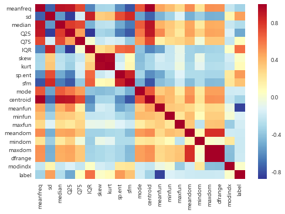

```python
# 모든 연속형 변수 간의 상관관계를 Heatmap 을 통해 확인하기
sns.heatmap(df.corr(),cmap='RdYlBu_r')
plt.show()
```

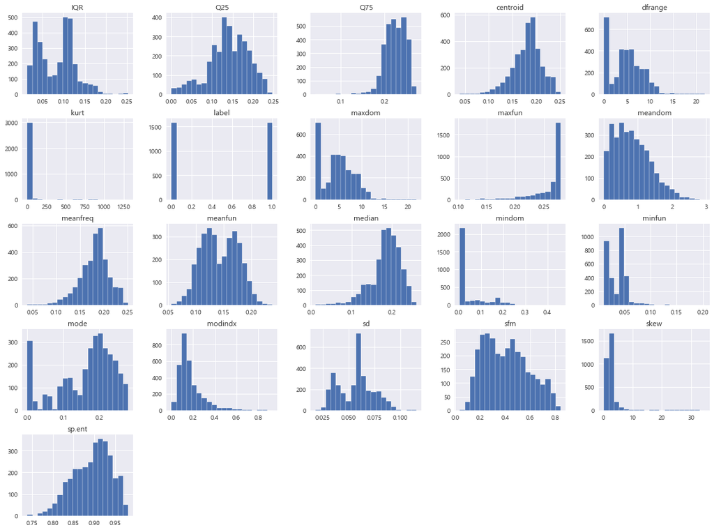

```python
# 모든 연속형 변수에 대한 히스토그램 한꺼번에 그리기
df.hist(bins=20, figsize=(20,15))    #bin 에 따라 막대의 굵기가 달라지넹 , fig_size에 따라 그래프의 크기가 달라짐.
plt.show()
```

```python
# data set 을 나누기 전에 데이터 크기가 어느정도인지 확인해보자

df.shape
```

```
(3168, 21)
```

```python
# feature 과 label를 나눈다.

X=df.iloc[:, :-1]   # feature
y=df.iloc[:,-1]     # label
```

```python
X_train, X_test, y_train, y_test = train_test_split(X, y, test_size = 0.3, random_state = 4) #:D random_state seed 설정해서 다시 돌려도
```

```python
# 제대로 나눠졌나 확인~
print(X_train.shape)
print(X_test.shape)
```

```
(2217, 20)
(951, 20)
```

#### 놓치지 말아야 할것

- split 다음에 scale 해주어야 한다는것.
- X_test 에 대해 scale 해줄때는 fit 없이 transform만 해주면 된다.

```python
sc = StandardScaler()
sc.fit(X_train) # :D assign 방식
```

```
StandardScaler(copy=True, with_mean=True, with_std=True)
```

```python
X_train = sc.transform(X_train) #:D fit_transform
X_test = sc.transform(X_test)
```

```python
X_train    # scaling 된것을 확인할수 있다.
```

```
array([[-1.30142635,  1.41307634, -1.6476778 , ..., -0.26947148,
        -0.25685138,  0.11706212],
       [ 0.33485003,  0.40954288,  0.23989355, ..., -1.33844524,
        -1.32830835,  1.23788296],
       [ 0.2071989 , -0.02241191,  0.75928597, ...,  0.11183256,
         0.09148236,  0.48075141],
       ...,
       [ 0.95481757, -1.52864233,  0.74167722, ...,  0.45566742,
         0.46406719, -0.42754552],
       [ 0.27041533,  0.79201299, -0.58122259, ..., -1.30318013,
        -1.2908294 ,  0.56473741],
       [ 0.40502978,  0.28343021,  0.16051537, ...,  1.07060284,
         1.07916286, -0.70716405]])
```

```python
X_test
```

```
array([[-0.83879278,  2.00978802,  0.36580449, ..., -1.23485397,
        -1.22248544,  1.0685126 ],
       [ 0.62437032, -0.07467827,  0.91804862, ...,  0.0655471 ,
         0.03416162, -0.53401688],
       [-1.2824008 ,  0.89943174, -1.58013633, ..., -0.72130575,
        -0.7088034 ,  0.5734968 ],
       ...,
       [ 0.66244584,  0.48516807,  0.90493174, ..., -1.26130281,
        -1.24894117, -0.18835651],
       [-1.02247645,  0.27416161, -1.36819599, ..., -0.4347767 ,
        -0.42137294,  0.12357781],
       [ 0.27719411, -0.06202123,  0.13595677, ...,  0.10522035,
         0.1135288 , -0.30155508]])
```

## 2-1. 모델선정

### SVM 을 이용해보자

svm 모델을 찾으면서 두개의 차이점이 궁금했는데 다음과 같다고 한다.

- svr :regression 용
- svc : classification 용 (분류문제)

```python
# 하이퍼 파라미터 튜닝 없이
svc = SVC()
svc.fit(X_train, y_train)
y_pred=svc.predict(X_test)
print('Accuracy score : ')
print(metrics.accuracy_score(y_test, y_pred))
```

```
Accuracy score :
0.9800210304942166
```

```python
svc = SVC(kernel='linear')
svc.fit(X_train, y_train)
y_pred=svc.predict(X_test)
print('Accuracy score : ',metrics.accuracy_score(y_test, y_pred))
print('R^2:',metrics.r2_score(y_test, y_pred))
print('Adjusted R^2:',1 - (1-metrics.r2_score(y_test, y_pred))*(len(y_test)-1)/(len(y_test)-X_train.shape[1]-1))
print('MAE:',metrics.mean_absolute_error(y_test, y_pred))
print('MSE:',metrics.mean_squared_error(y_test, y_pred))
print('RMSE:',np.sqrt(metrics.mean_squared_error(y_test, y_pred)))
```

```
Accuracy score :  0.9726603575184016
R^2: 0.8906142167011732
Adjusted R^2: 0.8882618342646393
MAE: 0.027339642481598318
MSE: 0.027339642481598318
RMSE: 0.1653470365068522
```

```python
svc = SVC(kernel='rbf')
svc.fit(X_train, y_train)
y_pred=svc.predict(X_test)
print('Accuracy score : ',metrics.accuracy_score(y_test, y_pred))
print('R^2:',metrics.r2_score(y_test, y_pred))
print('Adjusted R^2:',1 - (1-metrics.r2_score(y_test, y_pred))*(len(y_test)-1)/(len(y_test)-X_train.shape[1]-1))
print('MAE:',metrics.mean_absolute_error(y_test, y_pred))
print('MSE:',metrics.mean_squared_error(y_test, y_pred))
print('RMSE:',np.sqrt(metrics.mean_squared_error(y_test, y_pred)))
```

```
Accuracy score :  0.9800210304942166
R^2: 0.9200642352816266
Adjusted R^2: 0.9183451865780057
MAE: 0.019978969505783387
MSE: 0.019978969505783387
RMSE: 0.14134698265539095
```

### 하이퍼파라미터 튜닝

- SVM 매개변수 튜닝
- gamma : 가우시안 커널 폭의 역수 = 매개변수 하나의 훈련 샘플이 미치는 영향의 범위(작은값일수록 넓은 범위를 의미한다.)
- C: 각 포인트의 중요도 (dual_coef_값) 을 제한한다 . C를 증가시키면 포인트 들이 모델에 큰 영향을 줘서 결정경계를 휘어서 정확하게 분류하게 한다.

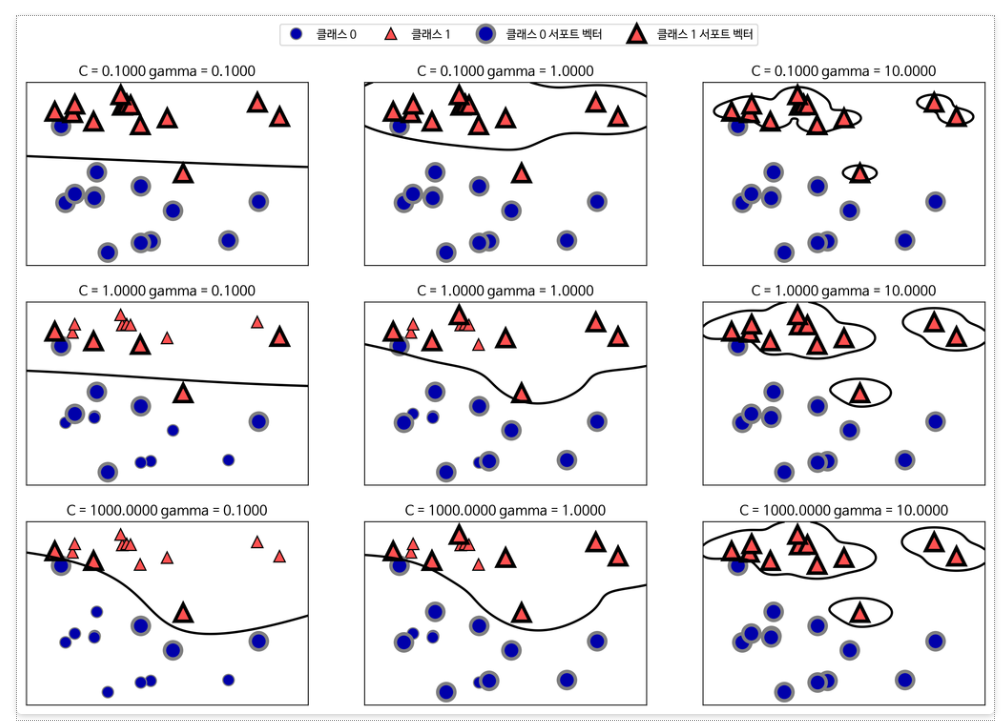

```python
parameters = {
    'gamma': [1, 0.1, 0.01, 0.001, 0.0001],
    'kernel':('rbf', 'linear', 'sigmoid', 'poly'),
    'C': [0.1, 1, 5, 10]
}

gridsearch = GridSearchCV(estimator = SVC(), param_grid  = parameters, cv = 3, scoring="accuracy",  n_jobs=-1, verbose = 10)
gridsearch.fit(X_train, y_train)
```

```
Fitting 3 folds for each of 80 candidates, totalling 240 fits
```

[output not shown]

```
GridSearchCV(cv=3, error_score=nan,
             estimator=SVC(C=1.0, break_ties=False, cache_size=200,
                           class_weight=None, coef0=0.0,
                           decision_function_shape='ovr', degree=3,
                           gamma='scale', kernel='rbf', max_iter=-1,
                           probability=False, random_state=None, shrinking=True,
                           tol=0.001, verbose=False),
             iid='deprecated', n_jobs=-1,
             param_grid={'C': [0.1, 1, 5, 10],
                         'gamma': [1, 0.1, 0.01, 0.001, 0.0001],
                         'kernel': ('rbf', 'linear', 'sigmoid', 'poly')},
             pre_dispatch='2*n_jobs', refit=True, return_train_score=False,
             scoring='accuracy', verbose=10)
```

```python
print('--- best_params_ ---')
print(gridsearch.best_params_)
print('--------------------')

print('--- best_score_ ----')
print(gridsearch.best_score_)
print('--------------------')

print('--- cv_results_ ----')
print(gridsearch.cv_results_['params'])
print(gridsearch.cv_results_)
print('--------------------')
```

[output not shown]

[output cut: 160 more lines]

[output not shown]

## 2-2. 모델선정

### Regression - pipeline 이용하기

#### 하이퍼파라미터 튜닝 없이 pipeline을 이용해보자!

```python
# 처음부터 다시 split
X_train, X_test, y_train, y_test = train_test_split(X, y, test_size = 0.3, random_state = 4) #:D random_state seed 설정해서 다시 돌려도
```

```python
%whos DataFrame
```

```
Variable   Type         Data/Info
---------------------------------
X          DataFrame          meanfreq        sd <...>n[3168 rows x 20 columns]
X_test     DataFrame          meanfreq        sd <...>\n[951 rows x 20 columns]
X_train    DataFrame          meanfreq        sd <...>n[2217 rows x 20 columns]
df         DataFrame          meanfreq        sd <...>n[3168 rows x 21 columns]
```

```python
X_train.shape
```

```
(2217, 20)
```

```python
from sklearn.pipeline import Pipeline
from sklearn.linear_model import LogisticRegression

my_pipe = Pipeline(steps=[
    ('sc', StandardScaler()), #:D tuple 앞 string은 지정하는 이름
    ('LR',LogisticRegression())
])
```

```python
my_pipe.fit(X_train, y_train) #:D 훈련 데이터를 변환하고 변환된 데이터에 학습시킨다.
cross_val_score(my_pipe, X_train, y_train, cv=5, scoring = 'accuracy').mean()
```

```
0.9729292497915523
```

```python
from sklearn.metrics import confusion_matrix

y_pred = my_pipe.predict(X_test)
conf_mat = confusion_matrix(y_test, y_pred)
```

```python
conf_mat
```

```
array([[455,  13],
       [ 14, 469]], dtype=int64)
```

```python
## X_train이 원래 상태 유지함을 확인
# pipeline을 사용하면 데이터 자체는 변하지 않는군,,,??!?

pd.DataFrame(X_train).head(3)
```

|  | meanfreq | sd | median | Q25 | Q75 | IQR | skew | kurt | sp.ent | sfm | mode | centroid | meanfun | minfun | maxfun | meandom | mindom | maxdom | dfrange | modindx |
| --- | --- | --- | --- | --- | --- | --- | --- | --- | --- | --- | --- | --- | --- | --- | --- | --- | --- | --- | --- | --- |
| 66 | 0.141153 | 0.080922 | 0.124305 | 0.097152 | 0.222242 | 0.125090 | 1.724298 | 6.313517 | 0.949959 | 0.646653 | 0.109395 | 0.141153 | 0.117298 | 0.018868 | 0.258065 | 0.639617 | 0.007812 | 4.062500 | 4.054688 | 0.187230 |
| 1643 | 0.190769 | 0.064057 | 0.194051 | 0.148141 | 0.248503 | 0.100362 | 1.119932 | 3.519070 | 0.939460 | 0.579687 | 0.144671 | 0.190769 | 0.138084 | 0.017279 | 0.271186 | 0.184152 | 0.015625 | 0.273438 | 0.257812 | 0.319347 |
| 429 | 0.186898 | 0.056797 | 0.213243 | 0.125405 | 0.229189 | 0.103784 | 2.589224 | 10.736947 | 0.896890 | 0.383985 | 0.218378 | 0.186898 | 0.114696 | 0.022663 | 0.271186 | 0.879185 | 0.125000 | 5.414062 | 5.289062 | 0.230100 |

## 2-3. 모델 선정

### autoML 을 이용해보자

conda install -c conda-forge tpot

http://epistasislab.github.io/tpot/installing/

```python
from tpot import TPOTClassifier
from tpot import TPOTRegressor

tpot = TPOTClassifier(generations=5,verbosity=2, config_dict='TPOT light')

tpot.fit(X_train, y_train)
```

```
Generation 1 - Current best internal CV score: 0.9697730461838814
Generation 2 - Current best internal CV score: 0.9697730461838814
Generation 3 - Current best internal CV score: 0.9720344497996868
Generation 4 - Current best internal CV score: 0.9720344497996868
Generation 5 - Current best internal CV score: 0.972482866613792

Best pipeline: DecisionTreeClassifier(DecisionTreeClassifier(input_matrix, criterion=gini, max_depth=6, min_samples_leaf=3, min_samples_split=13), criterion=entropy, max_depth=6, min_samples_leaf=5, min_samples_split=16)
```

```
TPOTClassifier(config_dict='TPOT light', crossover_rate=0.1, cv=5,
               disable_update_check=False, early_stop=None, generations=5,
               max_eval_time_mins=5, max_time_mins=None, memory=None,
               mutation_rate=0.9, n_jobs=1, offspring_size=None,
               periodic_checkpoint_folder=None, population_size=100,
               random_state=None, scoring=None, subsample=1.0, template=None,
               use_dask=False, verbosity=2, warm_start=False)
```

```python
print(tpot.score(X_test, y_test))
```

```
0.9600420609884333
```

```python
# 지금 만들어진 dataframe을 볼수 있다.

%whos DataFrame
```

```
Variable   Type         Data/Info
---------------------------------
X          DataFrame          meanfreq        sd <...>n[3168 rows x 20 columns]
X_test     DataFrame          meanfreq        sd <...>\n[951 rows x 20 columns]
X_train    DataFrame          meanfreq        sd <...>n[2217 rows x 20 columns]
df         DataFrame          meanfreq        sd <...>n[3168 rows x 21 columns]
```